# Benchmarking circuits for Qiskit

[figure not shown]

This work provides a collection of quantum circuits that can be used to benchmark Qiskit, to keep track of the impact of the changes on its performance as codebase evolves or simply assert it at a given point in time.

The quantum circuits provided both span useful building blocks for larger quantum circuits, as well as application-related circuits. A few examples of the currently available ones are:

- random circuits
- QFT
- n-Toffoli gate
- Adders
- variational circuits for quantum chemistry (UCCSD)
- Bravyi-Haah distillation protocols

## Motivation

Users can compute various metrics from the benchmarking circuits, e.g

- Compare results
  - Accross papers
  - Qiskit version
  - Backends
- Specificaly, compare transpilers (size, depth, ...)
- Get performance metrics
  - simulators
  - Qiskit itself

## General-purpose quantum circuits

These circuits are building blocks that are used in a wide array or larger circuits. They are formulated at the highest-level of abstraction.

```python
from circuit_benchmarks.toffoli import toffoli
toffoli(4).draw()
```

```
         ┌───────────────┐
q0_0: |0>┤               ├
         │ ───────────── │
q0_1: |0>┤ C^3rx(3.1416) ├
         │ C^3rx(3.1416) │
q0_2: |0>┤ C^3rx(3.1416) ├
         │ ───────────── │
q0_3: |0>┤               ├
         └───────────────┘
```

```python
from circuit_benchmarks.ripple_adder import ripple_adder
ripple_adder(10).draw()
```

```
         ┌─────┐                                               ┌─────┐
q1_0: |0>┤     ├───────────────────────────────────────────────┤     ├
         │ ─── │                                               │ ─── │
q2_0: |0>┤ Maj ├───────────────────────────────────────────────┤ Uma ├
         │ ─── │┌─────┐                                 ┌─────┐│ ─── │
q2_1: |0>┤     ├┤     ├─────────────────────────────────┤     ├┤     ├
         └─────┘│ ─── │                                 │ ─── │└─────┘
q2_2: |0>───────┤ Maj ├─────────────────────────────────┤ Uma ├───────
                │ ─── │┌─────┐                   ┌─────┐│ ─── │
q2_3: |0>───────┤     ├┤     ├───────────────────┤     ├┤     ├───────
                └─────┘│ ─── │                   │ ─── │└─────┘
q2_4: |0>──────────────┤ Maj ├───────────────────┤ Uma ├──────────────
                       │ ─── │┌─────┐     ┌─────┐│ ─── │
q2_5: |0>──────────────┤     ├┤     ├─────┤     ├┤     ├──────────────
                       └─────┘│ ─── │     │ ─── │└─────┘
q2_6: |0>─────────────────────┤ Maj ├─────┤ Uma ├─────────────────────
                              │ ─── │     │ ─── │
q2_7: |0>─────────────────────┤     ├──■──┤     ├─────────────────────
                              └─────┘┌─┴─┐└─────┘
q3_0: |0>────────────────────────────┤ X ├────────────────────────────
                                     └───┘
```

## Using QFT circuits to benchmark

Quantum Fourier Transform is a very important subcircuit for many applications. We can use it to benchmark transpilers. For example see how they perform on diferent chip layouts, square, hexagonal or triangular lattices.

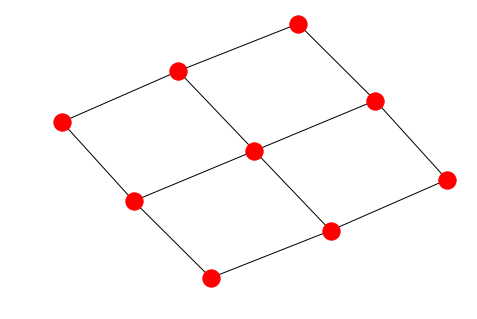

```python
g = grid_2d_graph(3,3)
pos = kamada_kawai_layout(g)
draw(g, pos)
```

For each grid we transpile a QFT circuit to that grid.

```python
for grid in grid_couplm:
    circuit = qft_circuit(grid.size())
    # Use Qiskit's Stochasit swap mapper
    stoch_qft = transpile(circuit, simulator, pass_manager=PassManager(StochasticSwap(grid)))
    stoch_circs.append(stoch_qft)
    # Use Sven's Lookahead swap mapper
    la_qft = transpile(circuit, simulator, pass_manager=PassManager(LookaheadSwap(grid)))
    la_circs.append(la_qft)
```

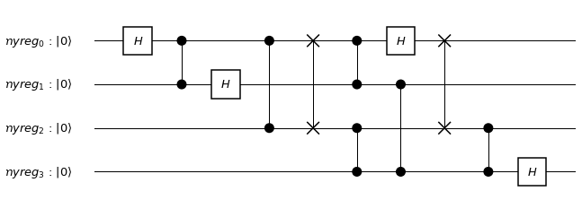

```python
stoch_circs[0].draw(output='mpl', scale=0.75)
```

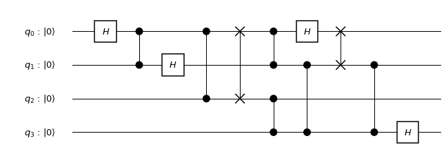

```python
la_circs[0].draw(output='mpl', scale=0.75)
```

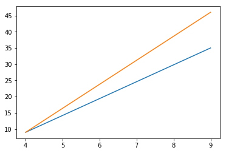

```python
import matplotlib.pyplot as plt

stoch_depth = [circ.depth() for circ in stoch_circs]
la_depth = [circ.depth() for circ in la_circs]
xs = [grid.size() for grid in grid_couplm]

plt.plot(xs, stoch_depth, xs, la_depth)
plt.draw()
```

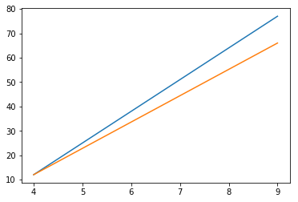

```python
stoch_size = [circ.size() for circ in stoch_circs]
la_size = [circ.size() for circ in la_circs]
xs = [grid.size() for grid in grid_couplm]

plt.plot(xs, stoch_size, xs, la_size)
plt.draw()
```

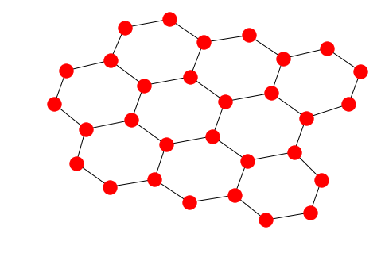

```python
g = hexagonal_lattice_graph(3,3)
pos = kamada_kawai_layout(g)
draw(g, pos)
```

## Application-specific quantum circuits

These circuits directly provide a way for users to benchmark the performance of Qiskit over particular applications of interest, and evaluate the feasibility of an approach on a target hardware, for example (runtime, hardware constraints on quantum volume...).

### Varitonal circuits in quantum chemistry

Some of these circuits are tied to a given problem, defined for example by a molecule and a basis set. The number of qubits required by these circuits, as well as the number of parameters used for the variational search is then determined accordingly. That is, these circuits cannot be simply fully-defined by a number of qubits provided as input; this is the case of the UCCSD variational form, for example. However, one can still observe how different metrics scale for these circuits by varying problem size (e.g the molecule or basis set), which makes sense for users that are focused on concrete applications in the field.

The code provides functions allowing to generate these UCCSD circuits for various molecules, basis sets and active spaces. The benchmark can be enriched by users, inputing their own problem and adding the corresponding circuit to the benchmark.

This approach can be generalized easily to different ansatz, or active spaces, allowing the user to determine what is the best approach to running for example VQE. They could then identiify the feasible approaches on the target hardware, and the parameters yielding the most appealing performance-accuracy trade-off.

[figure not shown]

# Magic State Factory

Circuits for magic state distillation are also interesting since they will be a big part of any error-corrected quantum computation. Several families of distillation protocols exist, we implemented the protocol by Bravyi and Haah, distilling 2k magic states from 6k+8 initial noisier magic states. Here is the smallest example:

```python
nqs_bravyi_haah
```

```
[31, 43, 55, 67, 79, 91, 103, 115, 127, 139, 151, 163, 175, 187, 199]
```

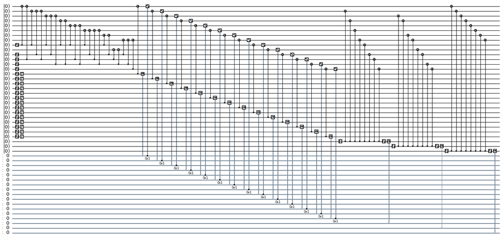

```python
circs_bravyi_haah[0].draw(output='mpl', scale=.2, style={'fold':150})
```